# Beiderman Uncertainty Expression

Amanda Pogue

2017-08-21

## Beiderman Uncertainty

The following document outlines the findings from Experiment 3 & 4 of the Uncertainty Project. These two experiments are simmilar to Experiments 1 & 2, in that the odd numbered experiments require the participant to rate their own certainty in the label in addition to labelling what they saw and picking a carrier phrase to describe that image to another person.

# Methods

*Participants:* 72 participants were recruited on Amazon’s Mechanical Turk (36 per experiment), and were compensated $0.50 for their participation. All participants reported living in the United States, and reported learning English at the age of 3 or younger. *Procedure:* Each participant randomly saw 5 trials. On each trial they were asked to label an image that they saw. 5 images were selected from Beiderman (1987), that were either whole line drawings of images (cup, glass, scissors, stool, watering can), geon interrupted (henceforth, nonrecoverable), or random segment deleted (henceforth, recoverable). These images were shown for 120, 220, or 750ms between 2 random dot arrays (to prevent the afterimage from completing the image). Each participant saw one of each item, the kind of deletion and duration of presentation was randomly selected per trial. The order of trials was also complete random. In **Experiment 3** participants rated their own label after producing it, whereas in **Experiment 4** participants just labelled the image and selected a carrier phrase with their label from a set of 8 items.

# Results

**Correct Label Results** The following graphs show the percentage of correct labels given the manipulations of *Time* and *Deletion*. As a note, I was very liberal in accepting some labels as being correct (if they seemed more or less reasonable, e.g. calling the watering can a “watering X” or a “kettle”).

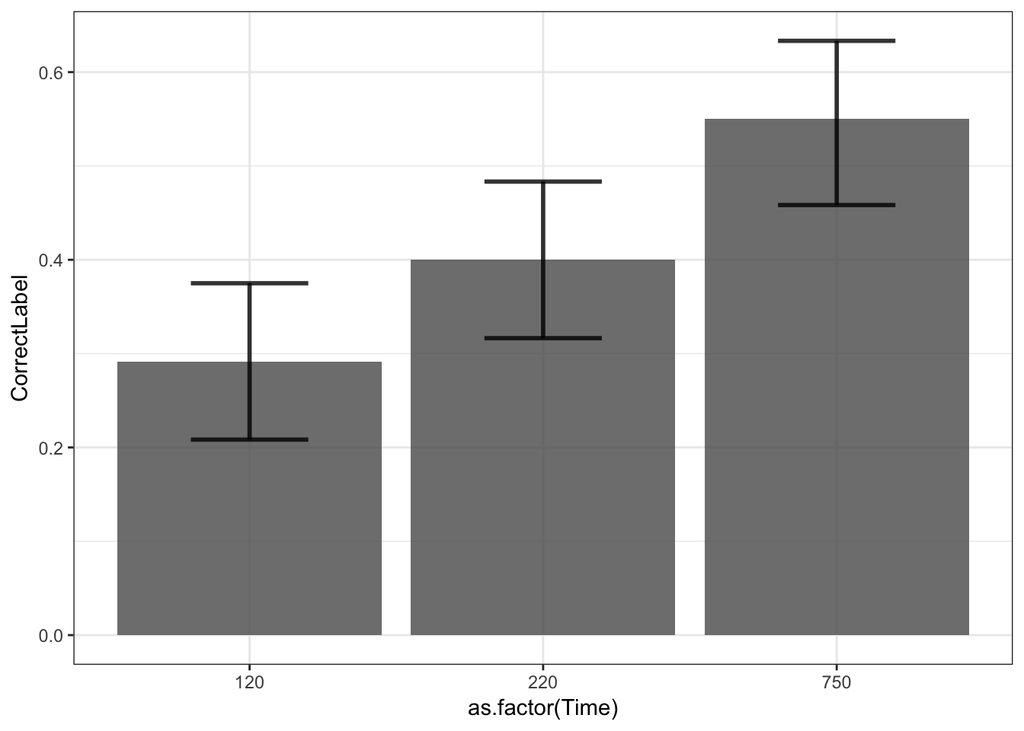

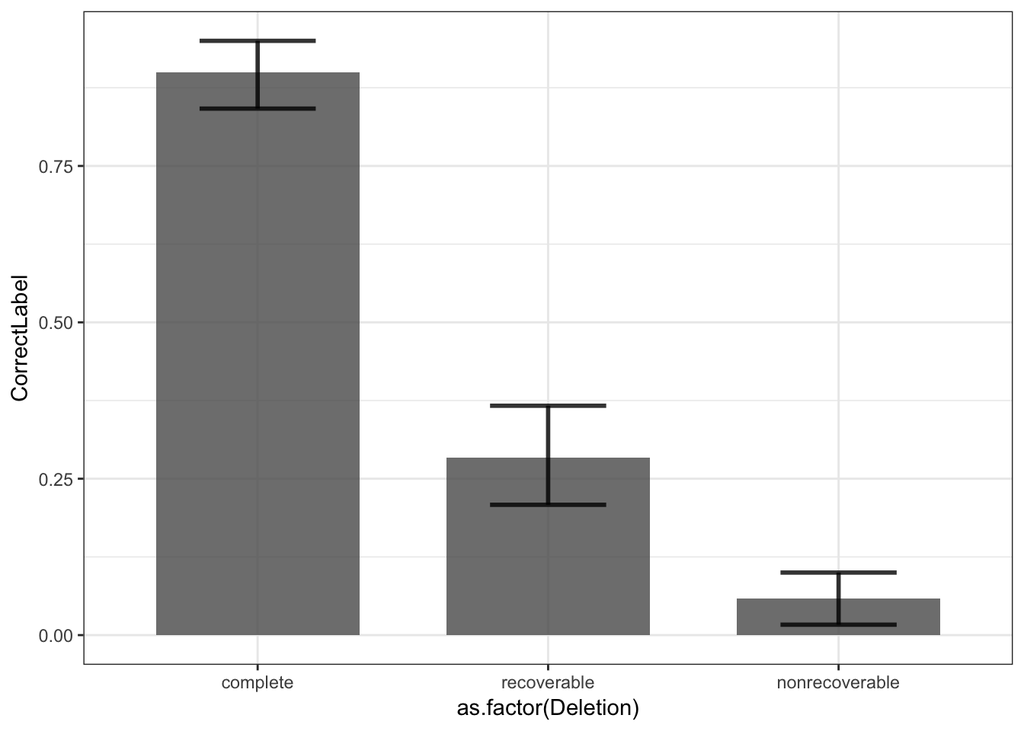

**Errors** The following graphs display the percentage of trials that Turkers reported only seeing dots/lines. Note, however, that this is a rough measure that doesn’t also include things like saying “not sure”.

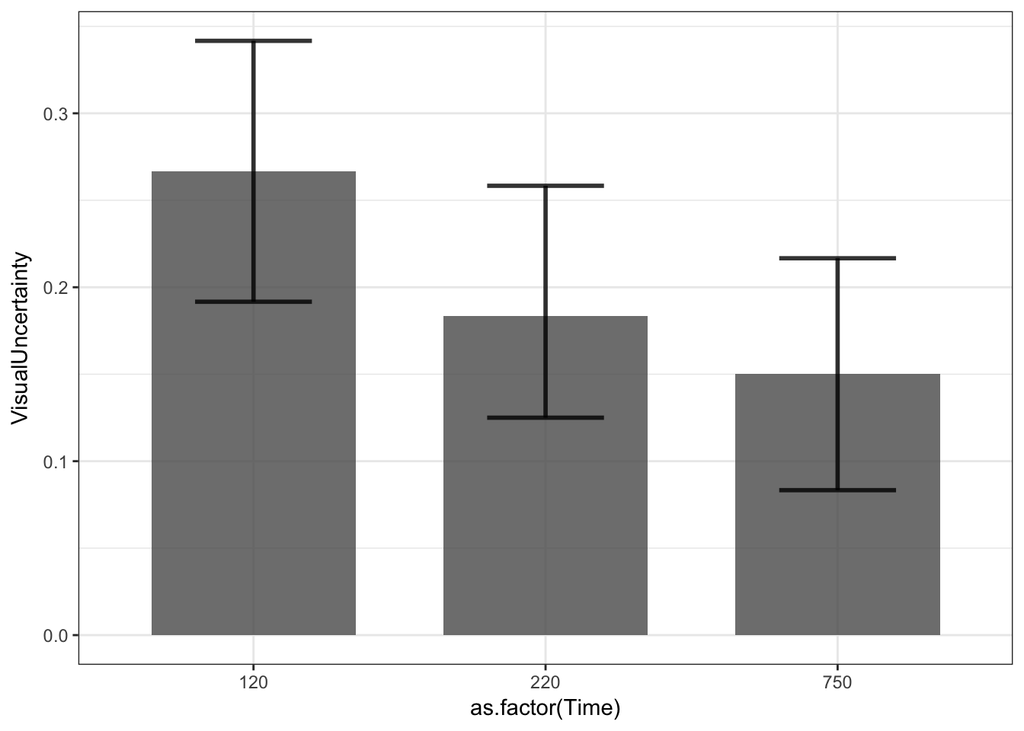

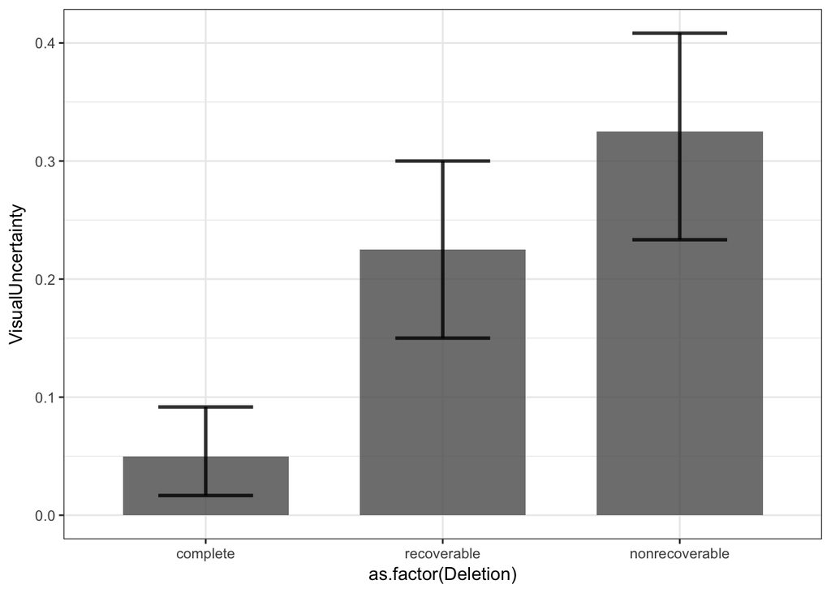

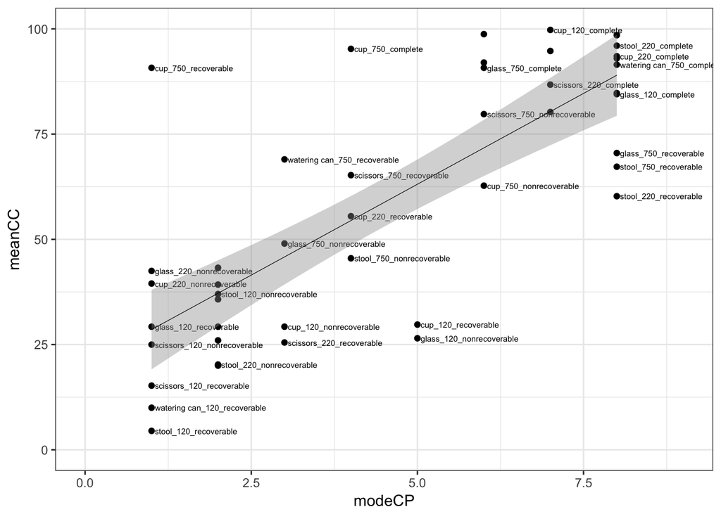

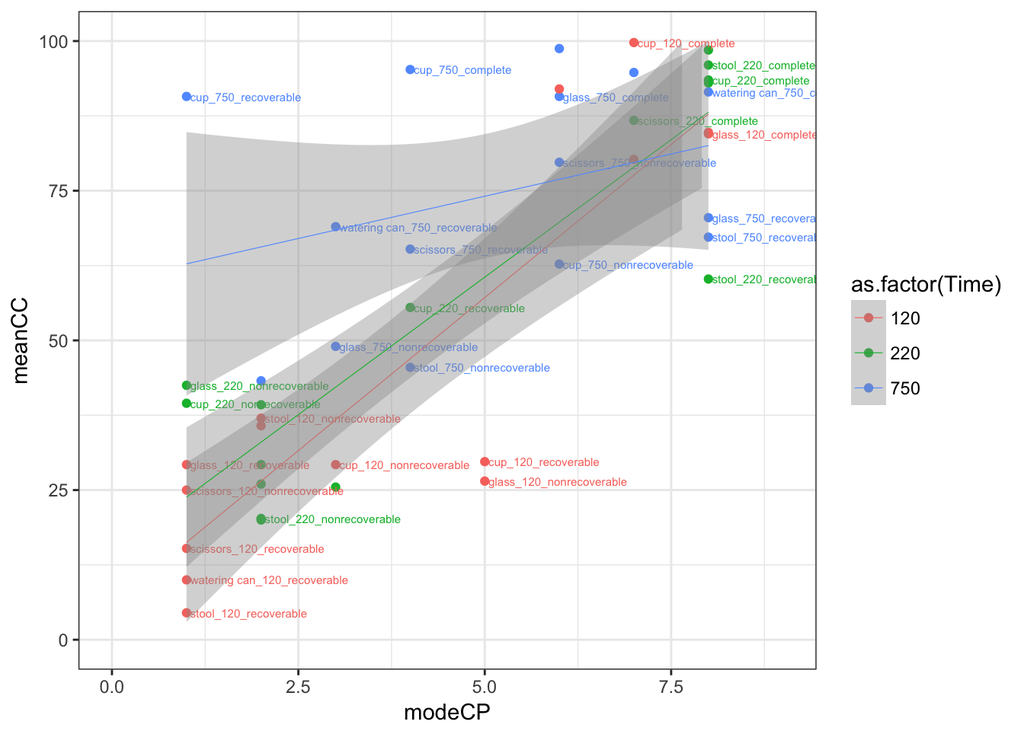

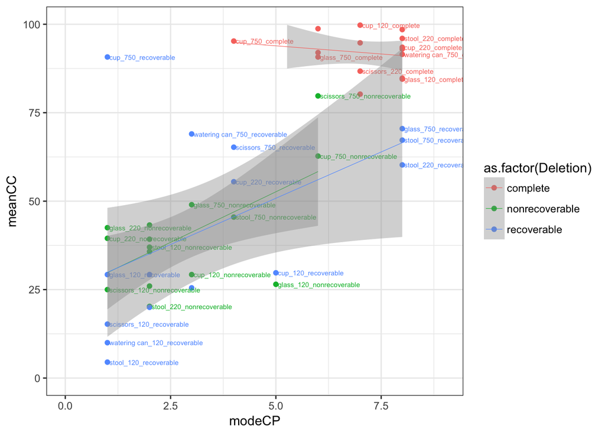

**Experiment 4** The data reported here is the mode response per item for Phrase selected compared to the mean confidence rating for each item in Experiment 3.

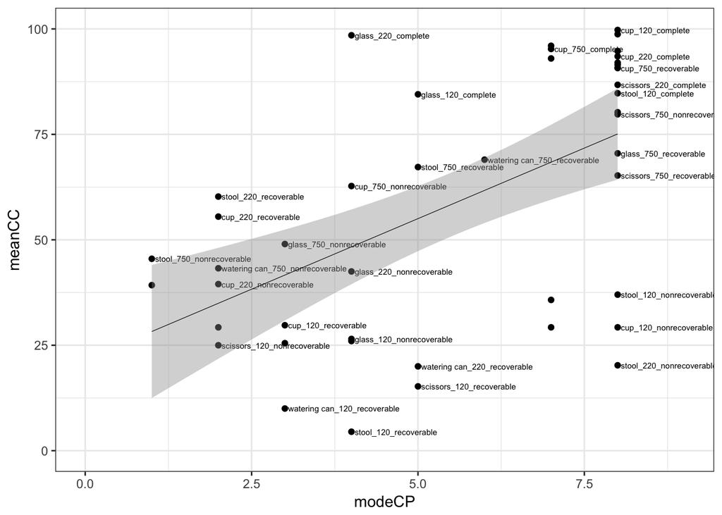

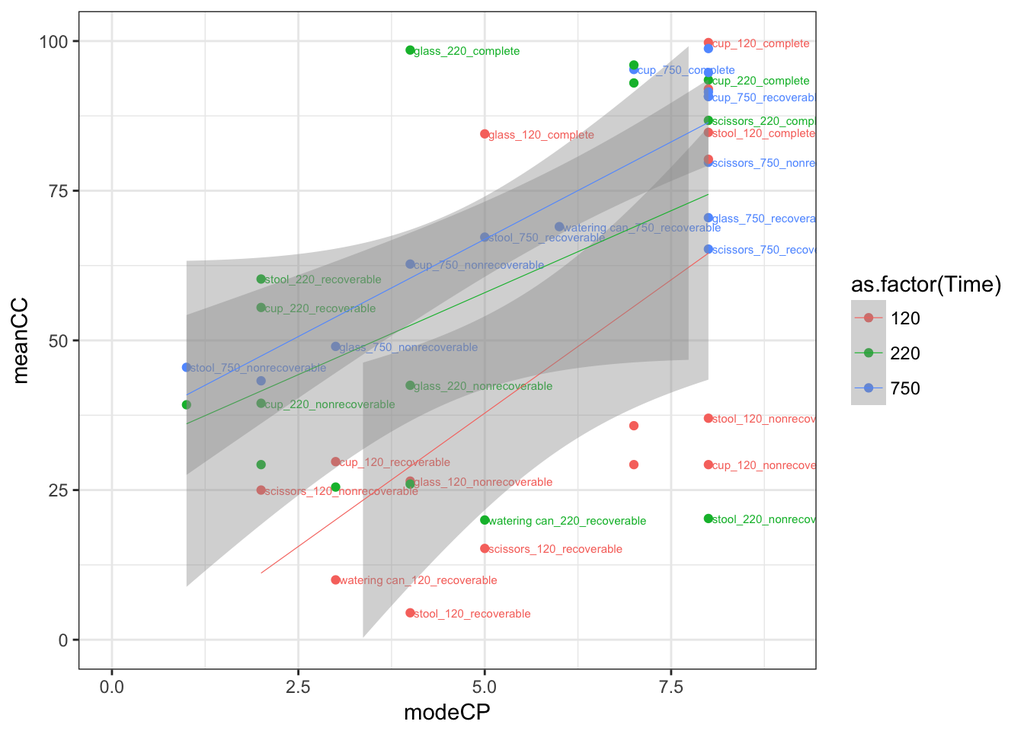

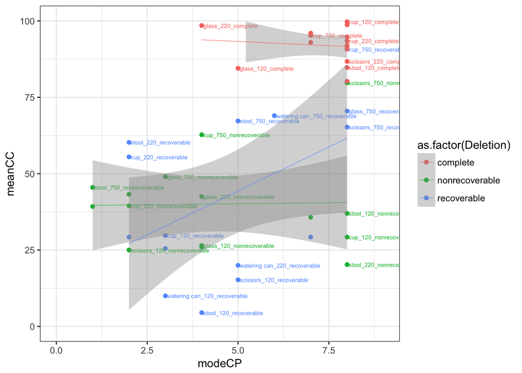